# CO2 ELEVATION, CANOPY PHOTOSYNTHESIS, ANDOPTIMAL LEAF AREA INDEX - Hirose - 1997 - Ecology - Wiley Online Library

[Ecology](https://esajournals.onlinelibrary.wiley.com/journal/19399170)

[Volume 78, Issue 8](https://esajournals.onlinelibrary.wiley.com/toc/19399170/1997/78/8) p. 2339-2350

# CO<sub>2</sub> ELEVATION, CANOPY PHOTOSYNTHESIS, ANDOPTIMAL LEAF AREA INDEX

[T. Hirose](https://esajournals.onlinelibrary.wiley.com/authored-by/Hirose/T.),

[D. D. Ackerly](https://esajournals.onlinelibrary.wiley.com/authored-by/Ackerly/D.+D.),

[M. B. Traw](https://esajournals.onlinelibrary.wiley.com/authored-by/Traw/M.+B.),

[D. Ramseier](https://esajournals.onlinelibrary.wiley.com/authored-by/Ramseier/D.),

[F. A. Bazzaz](https://esajournals.onlinelibrary.wiley.com/authored-by/Bazzaz/F.+A.),

First published: 01 December 1997

https://doi.org/10.1890/0012-9658(1997)078[2339:CECPAL]2.0.CO;2

## Abstract

We studied the effects of CO<sub>2</sub> elevation on leaf and canopy photosynthesis and optimal leaf area index (LAI) for stands of the annual species *Abutilon theophrasti* and *Ambrosia artemisiifolia.* Leaf photosynthesis was modeled as a function of photosynthetic photon flux density (PPFD) and nitrogen content per unit leaf area (*N*<sub>L</sub>). There was a curvilinear relationship between the light-saturated rates of leaf photosynthesis (*P*<sub>max</sub>) and *N*<sub>L</sub>. CO<sub>2</sub> elevation significantly increased *P*<sub>max</sub> as a function of *N*<sub>L</sub> in both species. Dark respiration (*R*<sub>d</sub>) was linearly correlated with *N*<sub>L</sub>. CO<sub>2</sub> elevation slightly but significantly increased *R*<sub>d</sub> in *Abutilon,* while it had no significant effect on *R*<sub>d</sub> in *Ambrosia.* The initial slope of a light-response curve was determined from quantum yield (φ<sub>abs</sub>) multiplied by leaf absorptance and then calibrated against *N*<sub>L</sub>. Daily canopy photosynthesis, calculated by integration of leaf photosynthesis with the actual distribution of leaf area, leaf N, and PPFD within a canopy, showed fairly good agreement with the canopy photosynthesis estimated from growth analysis. CO<sub>2</sub> elevation increased canopy photosynthesis by 30–50%. Based on the leaf photosynthesis model for *Abutilon,* we calculated daily canopy photosynthesis for a given LAI and N availability, in which N was assumed to be distributed optimally within a leaf canopy to maximize daily canopy photosynthesis. An optimal LAI to maximize daily canopy photosynthesis was obtained for each level of N availability and this optimum increased with increasing N availability. Contrary to the often predicted increase in LAI with CO<sub>2</sub> elevation, the optimum LAI did not increase at high CO<sub>2</sub> when N availability was limited. Two factors were suggested to be involved in counteracting the increase in LAI in a high-CO<sub>2</sub> world. One is the higher φ<sub>abs</sub> of plants grown in elevated CO<sub>2</sub>, which makes leaves in the canopy more N limited, favors higher *N*<sub>L</sub> and thus lowers optimal LAI. The other is the higher *R*<sub>d</sub> in elevated CO<sub>2</sub>, which leads to higher light compensation points, and lowers optimal LAI.

## Introduction

Elevation in atmospheric CO<sub>2</sub> concentration is believed to increase dry mass productivity of C<sub>3</sub> plants (Bazzaz 1990). Increase in productivity of a plant canopy may result from increasing leaf area index (LAI, total leaf area per unit ground area) as well as from increasing photosynthetic activity of leaves. Conflicting results, however, have been reported on the effect of CO<sub>2</sub> elevation on leaf area development, e.g., LAI increased with CO<sub>2</sub> elevation in the canopy of perennial ryegrass (Nijs et al. 1988), soybean (Cambell et al. 1990), and rice (Rowland-Bamford et al. 1991), while it remained the same in artificial tropical forest ecosystems (Körner and Arnone 1992). Studying the effect of CO<sub>2</sub> elevation on canopy development in two co-occurring annuals, we showed a strong correlation between LAI and aboveground plant nitrogen (Hirose et al. 1996*b*). Since there was no significant difference between CO<sub>2</sub> levels in the regression of LAI against aboveground N, we hypothesized that leaf area development is controlled primarily by the amount of N available for plant growth. This hypothesis suggests that the LAI would increase with CO<sub>2</sub> elevation if and only if N uptake from the soil is simultaneously increased, e.g., due to increased substrate supply for root growth. In order to further investigate this hypothesis, in this paper we present a model of canopy photosynthesis, based on the distribution of leaf N and photosynthetic photon flux density (PPFD) through the canopy, and we analyze the effects of CO<sub>2</sub> elevation and N availability on canopy photosynthesis and LAI. The gradient of leaf N that develops in parallel with a gradient of light climate is incorporated into the model, because it strongly influences canopy photosynthesis (Hirose and Werger 1987*b*).

In this paper we first show leaf N distribution in the canopy of monospecific and mixed stands of two co-occurring annual species (*Abutilon theophrasti* and *Ambrosia artemisiifolia*) established under ambient (360 μL/L) and elevated (700 μL/L) CO<sub>2</sub> conditions. Second, we model leaf photosynthesis as a function of leaf N and incident PPFD, taking account of the effect of CO<sub>2</sub> elevation on the light-saturated rate, dark respiration, and the initial slope of light-response curve. Third, canopy photosynthesis is calculated for monospecific and mixed stands of the two species established under ambient and elevated CO<sub>2</sub> conditions. These different combinations provide a variety of canopy structures that are used to validate our canopy photosynthesis model. And finally, we determine optimal LAI that maximizes daily canopy photosynthesis with a given amount of N for leaf growth, where N was distributed optimally in the canopy. We show that the optimal LAI does not increase with CO<sub>2</sub> elevation when the availability of N for leaf growth is limited.

## Materials and Methods

### Determination of canopy structure

The experiment to determine canopy structure was conducted at the Harvard University OEB Glasshouse in March–May 1994, using seeds of *Abutilon* and *Ambrosia* from an Illinois seed supply company (Hirose et al. 1996*b*). Seedlings were germinated and grown in round pots (0.1 m in diameter and 0.1 m deep) in either an ambient (360 μL/L) or elevated (700 μL/L) CO<sub>2</sub> atmosphere. Two-hundred and forty pots were placed contiguously in a square arrangement giving a density of 100 pots/m<sup>2</sup> in each of six CO<sub>2</sub> and temperature-controled zones. Plants were grown in pots to exclude root competition between individuals, allowing us to focus on interference in light interception and to reduce size variation among individuals. Adjacent zones were assigned to different CO<sub>2</sub> atmosphere treatments and were blocked together, for a total of three blocks. Temperature was maintained at 25°C day and 20°C night. Lighting was supplemented by halogen bulbs to extend day length (14 h). The photosynthetically active photon flux density (400–700 nm, PPFD) was up to 1200 μmol·m<sup>−2</sup>·s<sup>−1</sup> on clear days.

In order to obtain harvests of stands at two ages, we germinated a second set of seeds 2 wk after the first set. The same techniques were used as for the first set of seedlings. Plants of the younger group were fertilized on days 26, 29, and 35 with the same amount of fertilizer as the first stand. All of the plants of the two age groups were harvested together, when the plants in the older stands were 53 d old and the plants in the younger stands were 39 d old. Each day one of the three blocks was harvested. Before harvesting, stand light levels (PPFD) were measured at 0.05-m intervals from the ground with a line sensor (Sunfleck Ceptometer, Decagon, USA). The length of sensible part was reduced to 0.5 m with black tape to meet the size of the harvest area. The sensor was held horizontally during measurement and calibrated for the stand size. Relative PPFD was calculated against reference PPFD measured above the canopy with a point sensor (LI-185, LI-COR, Lincoln, Nebraska, USA), which was calibrated with the line sensor. Two measurements of light level were taken at each interval. Stand canopies were harvested from the top down in 0.05-m layers as measured from soil surface. At each layer, petioles and stems were combined. Leaf area of each layer was measured with a leaf area meter (LI-3000, LI-COR, Lincoln, Nebraska, USA). In the mixed stands, the plants of each species were harvested separately. Dry mass was determined after oven-drying at 50°C for >3 d. Dried plant materials were ground with a mill and their N contents were determined with a gas-chromatograph after combustion with circulating O<sub>2</sub> (NC-analyzer Sumigraph NC-80, Shimadzu, Japan).

### Determination of light-saturated rate, dark respiration, and the initial slope

In order to conduct detailed physiological measurements we established similar stands to those described above in 1995. Light-saturated rates of CO<sub>2</sub> exchange and the rate of dark respiration were measured in situ for leaves of *Abutilon* and *Ambrosia* in the glasshouse with a portable closed-gas-exchange measurement system (LI-6200, LI-COR, Lincoln, Nebraska, USA). Volume of the leaf chamber was 250 mL. The CO<sub>2</sub> concentration of the air at measurement was the same as that in which plants were grown. Air temperature in the leaf chamber was 26 ± 1°C. Measurement of the light-saturated rate of photosynthesis was done under sunny conditions with PPFD > 1000 μmol·m<sup>−2</sup>·s<sup>−1</sup>. Different leaves were used for measurement of dark respiration, which was done by wrapping the leaf chamber with a thick black cloth. Leaves were sampled from different heights along the stem, each representing a different leaf age and layer in the canopy. After leaf area measurement, leaf dry mass and N content were determined as described above. Rectangular hyperbolic equations were fitted to the relationship between leaf nitrogen per unit area (*N*<sub>L</sub>) and the light-saturated rate and linear equations fitted to the relationship between *N*<sub>L</sub> and dark respiration.

The initial slope of a light-response curve (φ) is a quantum yield (φ<sub>abs</sub>) multiplied by leaf absorptance (Hikosaka and Terashima 1995). Quantum yield increases with increasing CO<sub>2</sub> concentration (Ehleringer and Björkman 1977, Pearcy and Björkman 1983). We assumed φ<sub>abs</sub> = 0.05 at the atmospheric CO<sub>2</sub> concentration of 360 μL/L and φ<sub>abs</sub> = 0.07 at 700 μL/L CO<sub>2</sub>, using data in Ehleringer and Björkman (1977). Leaf absorptance (α) was calculated following Evans (1994):

((1))

α = *c*/(*c* + 0.076)

where *c* is chlorophyll content per unit leaf area in millimoles per square meter. Chlorophyll content was measured with a chlorophyll meter (SPAD-502, Minolta, Japan). SPAD values were calibrated with independent determinations of chlorophyll content following the procedure of Moran (1982). SPAD values were also calibrated with *N*<sub>L</sub> and we obtained relationships between N and chlorophyll content, which were fitted to a nonrectangular hyperbola equation. Thus we could calculate the initial slope for a leaf with a given *N*<sub>L</sub>.

((2))

τ = 0.41 exp(−4.0*c*) (*r*<sup>2</sup> = 0.98)

### Modeling leaf and canopy photosynthesis

Following Hirose and Werger (1987*a*), we employed a nonrectangular hyperbolic equation to characterize the light response of leaf photosynthesis:

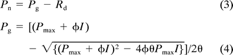

where *P*<sub>n</sub> is the CO<sub>2</sub> exchange rate (net photosynthetic rate), *P*<sub>g</sub> is gross photosynthesis (net photosynthesis plus dark respiration), *R*<sub>d</sub> is dark respiration, *I* is PPFD incident on a leaf, *P*<sub>max</sub> is the light-saturated rate of gross photosynthesis, φ is the initial slope, θ is the curvature factor. *P*<sub>max</sub>, *R*<sub>d</sub>, and φ are functions of *N*<sub>L</sub> (see *Determination of light-saturated rate* ... above). θ = 0.8 was assumed as an average value taken from several previous studies (Hirose and Werger 1987*a*, Pons et al. 1990, Anten et al. 1995*b*). Thus CO<sub>2</sub> exchange rates of leaves can be calculated based on *N*<sub>L</sub> and incident PPFD.

To calculate canopy photosynthesis we assumed that PPFD on a horizontal surface in a canopy attenuates exponentially with increasing LAI cumulated from the top of the canopy (*F*) and that the attenuation is due to PPFD absorption of leaves. Then the PPFD incident on a leaf (*I*) at depth *F* is given by

((5a))

*I* = *I*<sub>0</sub>*K* exp(−*KF*)/(1 − τ)

where *I*<sub>0</sub> is the PPFD on a horizontal surface above the canopy, *K* is the light extinction coefficient, and τ is the leaf transmittance (Monsi and Saeki 1953, Saeki 1960). For the calculation of canopy photosynthesis of the mixed stand, each species was assumed to contribute to the PPFD attenuation in proportion to its leaf area distribution and *K* value. Let *I*<sub>1</sub> and *I*<sub>2</sub> be the PPFD incident on a leaf of species 1 and 2 at depth *F,* respectively, then

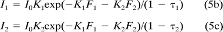

where *F*<sub>1</sub> and *F*<sub>2</sub> are cumulative leaf area at depth *F* in the canopy, *K*<sub>1</sub> and *K*<sub>2</sub> are the extinction coefficients, and τ<sub>1</sub> and τ<sub>2</sub> are the transmittance of species 1 and 2, respectively. Note that *F* = *F*<sub>1</sub> + *F*<sub>2</sub>. Leaf transmittance changes through the canopy and is given as a function of *N*<sub>L</sub> (see *Determination of light-saturated rate* ... above).

The daily course of PPFD above the canopy (*I*<sub>0</sub>) is assumed to follow a squared sine curve with a 14-h daylength:

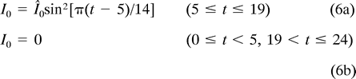

where *t* is the solar time (in hours) and *Î*<sub>0</sub> is the PPFD at midday (*t* = 12). *Î*<sub>0</sub> = 1200 μmol·m<sup>−2</sup>·s<sup>−1</sup> was assumed in the calculation. Air temperature was 25°C in daytime and 20°C at night with an assumption of *Q*<sub>10</sub> = 2 for *R*<sub>d</sub>.

The daily total canopy carbon exchange rate (*P*<sub>day</sub>) is an integration of instantaneous leaf photosynthesis with respect to depth (*F*) in the canopy and to time (*t*) in a day:

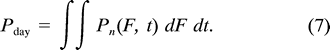

Incorporating actual distribution of leaf area and leaf N, we calculated daily canopy photosynthesis of the monospecific and mixed stands of *Abutilon* and *Ambrosia.*